# GenomicRanges and Related Packages Demo

## Introduction

This document demonstrates the core concepts of working with genomic intervals in Bioconductor. It covers foundational integer ranges (`IRanges`), base-level run-length encoding (`Rle`), full genomic ranges with chromosome and strand information (`GenomicRanges`), and retrieving transcript annotations (`GenomicFeatures`).

### Introduction to IRanges

The `IRanges` package provides the foundation for representing sequences of integers. This chunk shows how to create basic interval objects using start/end coordinates or start/width combinations, and how to access their properties.

```r
#####################################################
## first on IRanges
#####################################################
library(IRanges)

# Create an IRanges object by specifying start and end points
r <- IRanges(start=c(1,3,12, 10), end=c(4, 5, 25, 19))
r
```

```
## IRanges object with 4 ranges and 0 metadata columns:
##           start       end     width
##       <integer> <integer> <integer>
##   [1]         1         4         4
##   [2]         3         5         3
##   [3]        12        25        14
##   [4]        10        19        10
```

```r
# Alternatively, create the exact same IRanges object using start and width
r <- IRanges(start=c(1,3,12, 10), width=c(4,  3, 14, 10))
r
```

```
## IRanges object with 4 ranges and 0 metadata columns:
##           start       end     width
##       <integer> <integer> <integer>
##   [1]         1         4         4
##   [2]         3         5         3
##   [3]        12        25        14
##   [4]        10        19        10
```

```r
# Accessor functions to extract properties of the IRanges object
length(r) # Number of intervals in the object
```

```
## [1] 4
```

```r
start(r)  # Vector of start positions
```

```
## [1]  1  3 12 10
```

```r
end(r)    # Vector of end positions
```

```
## [1]  4  5 25 19
```

```r
width(r)  # Vector of interval widths
```

```
## [1]  4  3 14 10
```

```r
# Subset the IRanges object to keep only the first two intervals
r[1:2]
```

```
## IRanges object with 2 ranges and 0 metadata columns:
##           start       end     width
##       <integer> <integer> <integer>
##   [1]         1         4         4
##   [2]         3         5         3
```

### Visualizing Ranges

Because intervals can be abstract, this custom plotting function helps visualize them as staggered rectangles on a plot. We will use this to visualize the operations in the next chunk.

```r
# A small visualization function to plot intervals
plotRanges <- function(x, xlim = x, main = deparse(substitute(x)), col = "black", sep = 0.5, ...) {
  height <- 1
  # Determine the x-axis limits based on the min/max of the ranges
  if (is(xlim, "Ranges"))
    xlim <- c(min(start(xlim)), max(end(xlim)))

  # Calculate staggered bins so overlapping ranges don't plot on top of each other
  bins <- disjointBins(IRanges(start(x), end(x)+1))

  # Initialize the plot canvas
  plot.new()
  plot.window(xlim, c(0, max(bins)*(height+sep)))

  # Calculate y-coordinates for drawing the rectangles
  ybottom <- bins * (sep + height) - height

  # Draw the ranges as rectangles
  rect(start(x)-0.5, ybottom, end(x)+0.5, ybottom+ height, col = col, ...)

  # Add title and x-axis
  title(main)
  axis(1)
}
```

### Single IRanges Operations

This chunk demonstrates intra-range operations (transforming existing ranges) and inter-range operations (comparing ranges within a single object to each other), plotting the results.

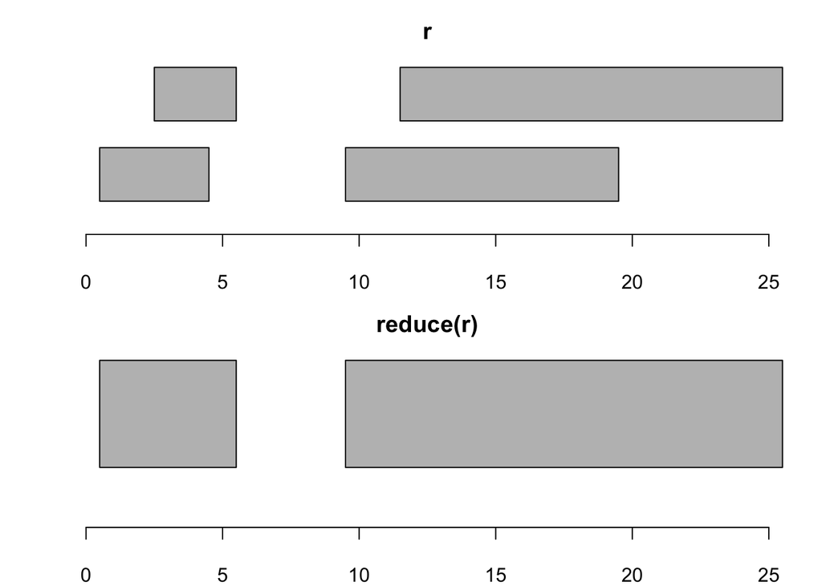

```r
# Set up plotting parameters for stacked plots
par(mar = c(2.5, 2.5, 2.6, 1.1), mgp = c(5.5, 1.5, 0), mfrow=c(2,1))

# Compare original ranges vs. reduced ranges
plotRanges(r, xlim=c(0,25), col="grey")
# reduce() merges all overlapping or adjacent ranges into a single continuous range
plotRanges(reduce(r), xlim=c(0,25), col="grey")
```

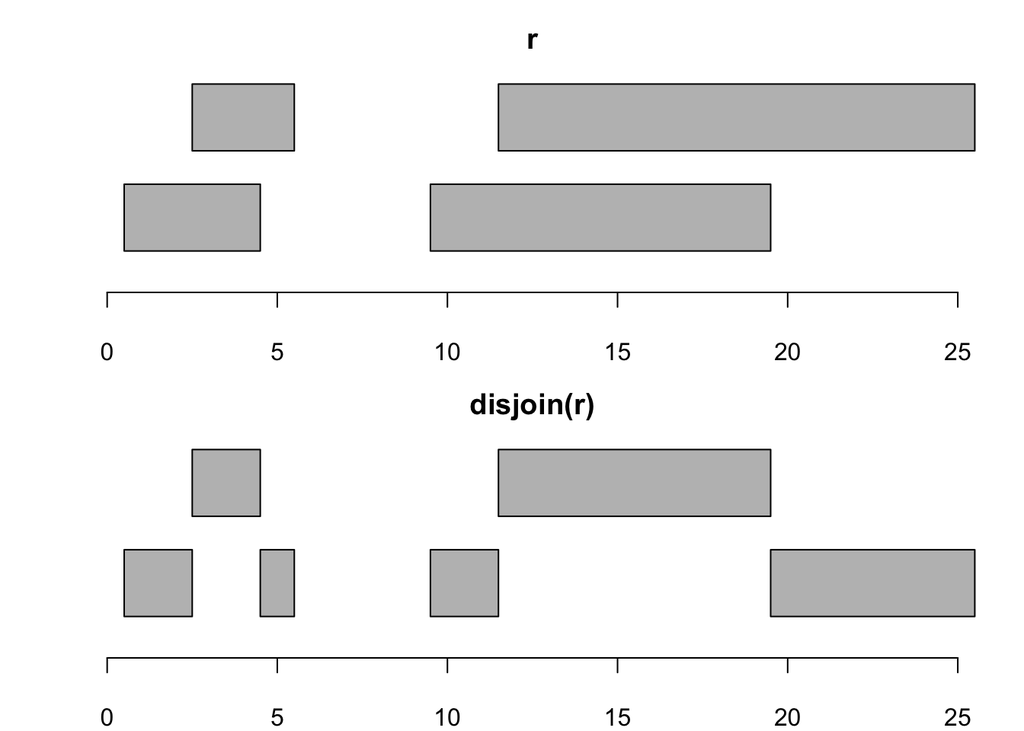

```r
par(mar = c(2.5, 2.5, 2.6, 1.1), mgp = c(5.5, 1.5, 0), mfrow=c(2,1))
plotRanges(r, xlim=c(0,25), col="grey")
# disjoin() breaks ranges into the largest set of non-overlapping contiguous intervals
plotRanges(disjoin(r), xlim=c(0,25), col="grey")
```

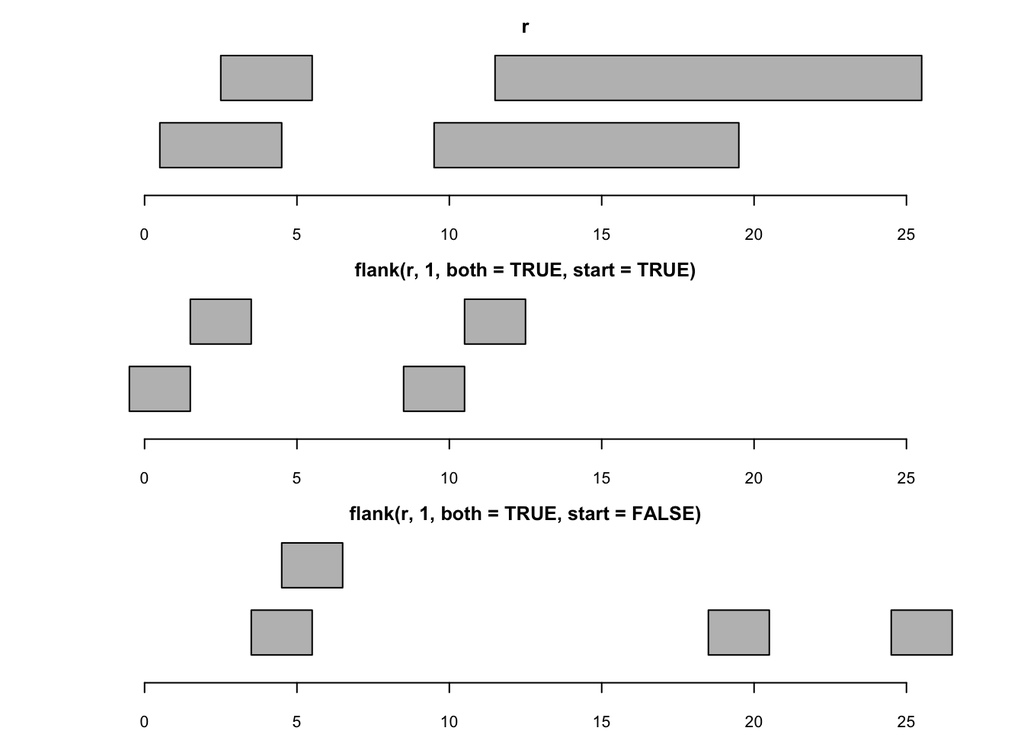

```r
par(mar = c(2.5, 2.5, 2.6, 1.1), mgp = c(5.5, 1.5, 0), mfrow=c(3,1))
plotRanges(r, xlim=c(-2,27), col="grey")
# flank() creates new ranges of width 1 adjacent to the starts of the original ranges (upstream/downstream)
plotRanges(flank(r, 1, both=TRUE, start=TRUE), xlim=c(-2,27), col="grey")
plotRanges(flank(r, 1, both=TRUE, start=FALSE), xlim=c(-2,27), col="grey")
```

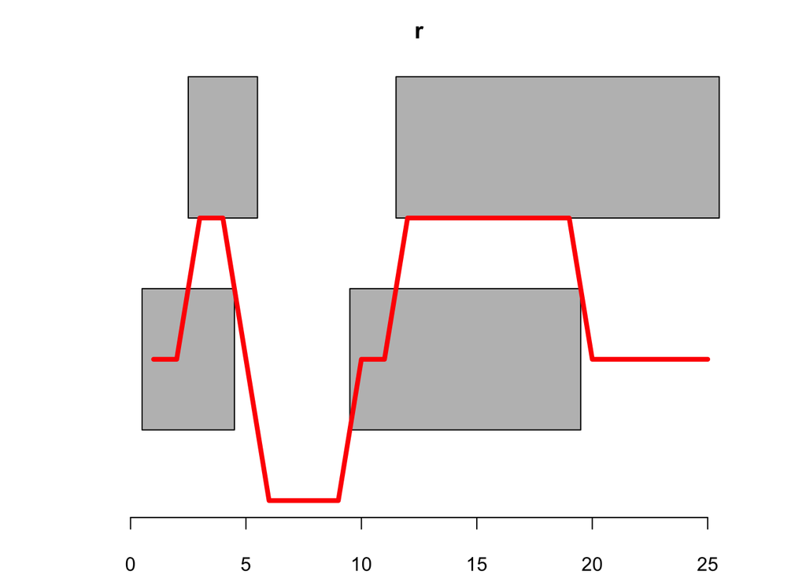

```r
par(mar = c(2.5, 2.5, 2.6, 1.1), mgp = c(5.5, 1.5, 0), mfrow=c(1,1))
plotRanges(r, xlim=c(-2,27), col="grey")
# coverage() calculates exactly how many ranges overlap at every single integer position
lines(coverage(r), lwd=4, col="red")
```

### Operations Between Two IRanges

Here we explore operations *between* two different sets of ranges, calculating standard set theory operations (union, intersection, difference) and finding overlaps.

```r
##### two ranges
# Create a second set of intervals
r2 = IRanges(start=c(8, 9, 15), end=c(10, 15, 17))
r2
```

```
## IRanges object with 3 ranges and 0 metadata columns:
##           start       end     width
##       <integer> <integer> <integer>
##   [1]         8        10         3
##   [2]         9        15         7
##   [3]        15        17         3
```

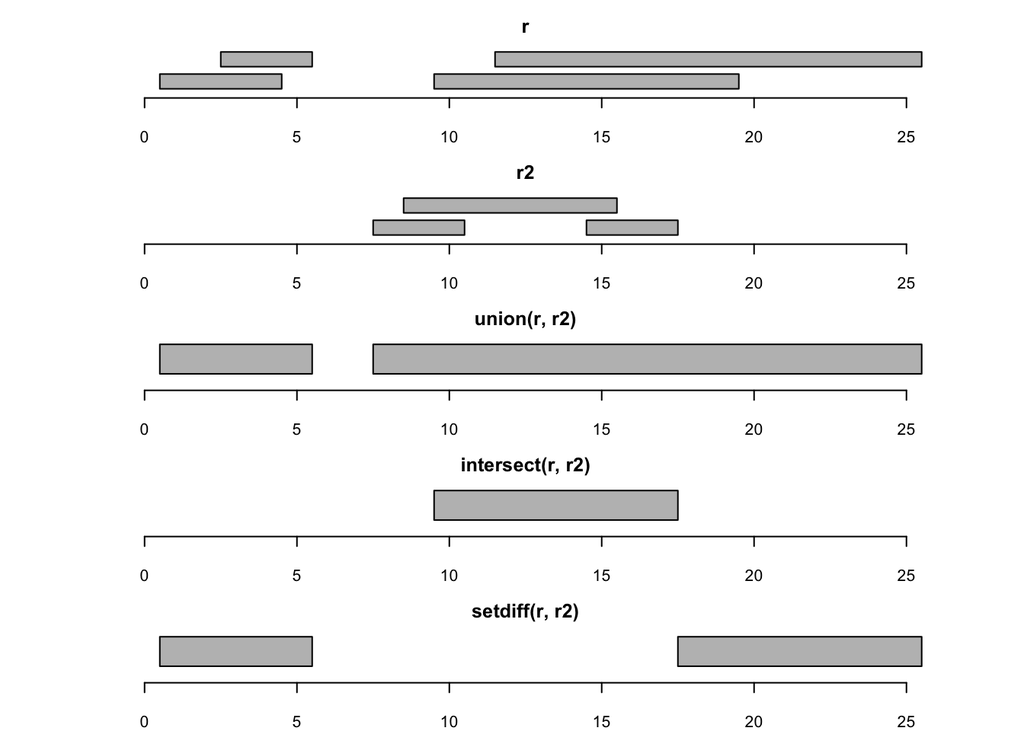

```r
par(mar = c(2.5, 2.5, 2.6, 1.1), mgp = c(5.5, 1.5, 0), mfrow=c(5,1))
plotRanges(r, xlim=c(-2,27), col="grey")
plotRanges(r2, xlim=c(-2,27), col="grey")
# union: intervals that are in r OR r2
plotRanges(union(r, r2), xlim=c(-2,27), col="grey")
# intersect: intervals that are in BOTH r AND r2
plotRanges(intersect(r, r2), xlim=c(-2,27), col="grey")
# setdiff: intervals in r that do NOT overlap with r2
plotRanges(setdiff(r, r2), xlim=c(-2,27), col="grey")
```

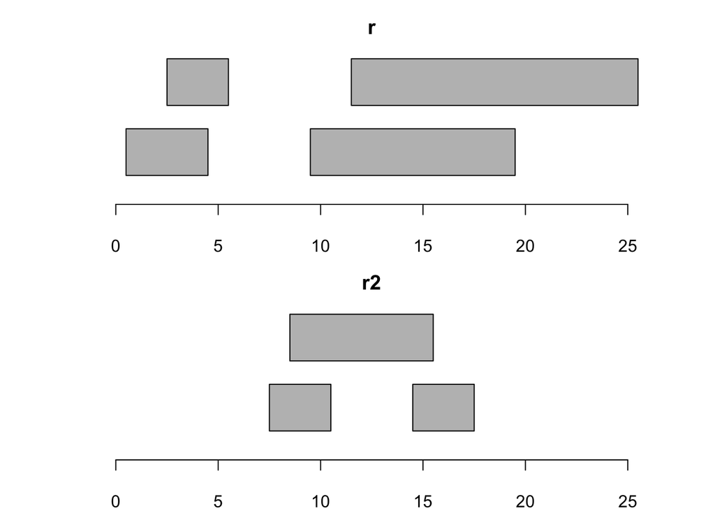

```r
par(mar = c(2.5, 2.5, 2.6, 1.1), mgp = c(5.5, 1.5, 0), mfrow=c(2,1))
plotRanges(r, xlim=c(-2,27), col="grey")
plotRanges(r2, xlim=c(-2,27), col="grey")
```

```r
# Count how many intervals in r2 overlap with each interval in r
countOverlaps(r, r2)
```

```
## [1] 0 0 2 3
```

```r
# Logical vector: TRUE if an interval in r overlaps any interval in r2
r %over% r2
```

```
## [1] FALSE FALSE  TRUE  TRUE
```

```r
# Detailed matrix/object showing exact indices of which ranges in r overlap with which ranges in r2
findOverlaps(r, r2)
```

```
## Hits object with 5 hits and 0 metadata columns:
##       queryHits subjectHits
##       <integer>   <integer>
##   [1]         3           2
##   [2]         3           3
##   [3]         4           1
##   [4]         4           2
##   [5]         4           3
##   -------
##   queryLength: 4 / subjectLength: 3
```